# riverconn vignette

Damiano Baldan

2022-06-17

## Indices to assess riverscape connectivity

### The river network as a graph

This package implements algorithms to compute commonly used indices to assess river networks fragmentation. All those indices assume a conceptualization of the river networks as a graph $L = (E,V)$, where vertices (nodes) $V$ represent single reaches, and edges (links) $E$ represent either confluences or longitudinal barriers.

[figure not shown]

### Generalized riverscape connectivity index

river networks-level connectivity can be expressed in terms of coincidence probability (Pascual-Hortal and Saura, 2006), i.e. the probability that two random points in a river network are connected. Once the coincidence probability $I_{ij}$ is defined for each couple of $i,j$ nodes in the graph, generalized connectivity indices for catchment and reach scales can be calculated.

##### Catchment Connectvity index

Given this conceptualization, a catchment-scale connectivity index (CCI) can be calculated as:

$$\ CCI = \sum_{i = 1}^{n} \sum_{j = 1}^{n} I_{ij} \frac{w_i w_j}{W^2}$$
Where $w_i$ and $w_j$ are some node-level attributes (weights), and $W$ is the sum of sum of the nodes weights for the whole river networks.

#### Reach Connectivity Index

A reach-scale connectivity index (RCI) can be calculated by limiting the summation to all the connections to the single node $i$.
$$\ RCI_i = \sum_{j = 1}^{n} I_{ij} \frac{w_j}{W}$$
#### Node weights Nodes weights can be arbitrarily chosen. Common features used are the reach length ($l_i$), area($A_i$), or volume($V_i$). Alternatively, the habitat suitability index (HSI) can be used, defined as the ratio of length/area that is suitable for a specific organism.
$$\ HSI_i = \frac{l_i,suitable}{l_i} \mbox{ ; } HSI_i =
\frac{A_i,suitable}{A_i}$$
Here $l_i,suitable$ and $A_i,suitable$ are the fractions of length/area of reach $i$ that are suitable, and are usually refferred to as weighted suitable length or weighted suitable area.

### Coincidence probability

$$\ I_{ij} = c_{ij}B_{ij}$$
where $c_{ij}$ is a ‘barrier coincidence probability’ depending on the presence of barriers between nodes $i$ and $j$, $f_{ij}$ is a ‘landscape coincidence probability’ depending on the landscape friction in the movement between nodes $i$ and $j$, and $B_{ij}$ is a ‘dispersal coincidence probability’ depends on the distance between nodes $i$ and $j$.

##### Coincidence probability for barriers

The barriers factor depends on the presence of barriers between nodes $i$ and $j$, and can be expressed as a function of the types of barriers present in the path expressed as a sequence of passability values. The passability $p_m$ for the $m$-th barrier is defined as the probability that the reaches immediately upstream and downstream the barrier $m$ are connected.

If the flow directionality is not relevant (i.e. the river graph is undirected),

$$\ c_{ij} = \prod_{m = 1}^{k} p_m^u p_m^d$$
Where the product extends over the $k$ nodes that are part of the path connecting reaches $i$ and $j$, $p_m^u$ is the upsstream passability of the $m$-th barrier and $p_m^u$ is the upstream passability of the $m$-th barrier. This definition based solely on products yields a symmetric coincidence probability (i.e. $c_{ij} = c_{ji}$).

A directional version of $c_{ij}$ can be defined as:
$$\ c_{ij} = \prod_{m = 1}^{k} p_m^{eq}$$
$$p_m^{eq} = \begin{cases}
p_m^u & \mbox{if barrier m is encountered moving upstream in the
path from i to j } \\
p_m^d & \mbox{if barrier m is encountered moving downstream in the
path from i to j }
\end{cases}$$
If $i$ and $j$ are located in different sub-catchments, the path from i to j will be moving downstream in some sections and upstream in some other secions: this $p_m^{eq}$ definition ensures the retained passability value is consistent with the directionality of the path from $i$ to $j$ (i.e. $c_{ij} \ne c_{ji}$)

##### Coincidence probability for dispersal

The dispersal coincidence probability can be calculated as a function of the distance between reaches. An exponential dispersal kernel can be used:

$$\ B_{ij} = PD^{d_{ij}}$$
where $PD$ is in the $(0,1)$ interval (smaller values mean more restricted movement), and $d_{ij}$ is the distance between reaches $i$ and $j$. Alternatively, a threshold based probability can be used:
$$\ B_{ij} = \begin{cases}
0 & \mbox{when } d_{ij}>d_{tr} \\
1 & \mbox{when } d_{ij}<=d_{tr}
\end{cases}$$
Both definitions can be easily adapted to asymmetric dispersal by defining $PD_{d}$, $PD_{u}$, $d_{tr,u}$, and $d_{tr,d}$, and calculating $B_{ij} = B_{ij}^u B_{ij}^d$ where $B_{ij}^u$ and $B_{ij}^d$ are the index $B_{ij}$ contribution calculated for the ‘downstream moving’ and ‘upstream moving’ sections in the path from reach $i$ to $j$.

The distance $d_{ij}$ can be either the geometric distance, or any other measure of effective distance (e.g. $d_{ij} / (1-HSI)$ provides an estimate of effective distance that depends on the habitat suitability index between reaches $i$ and $j$)

### Prioritization of barriers

All the defined connectivity index can be used to prioritize barriers removal with a ‘leave-one-out’ approach. For each barrier, the index $dCCI$ can be defined as:
$$\ dCCI_{m} = 100 \frac{CCI - CCI_{m, removed}}{GCI}$$
where $GCI$ is the generalized connectivity index calculated for the original river networks with all the barriers implemented, and GCI_{m, removed} is the index recalculated when barrier $m$ is removed or its passability is changed ($dRCI_{i}$ can be defined similarly) .

An alternative version of the index for prioritizing barriers can be calculated as the decrease in river networks connectivity after a single barrier is implemented, with a ‘add-one’ approach.

### Time-dependent connectivity

when barriers metadata on the year of construction and the year of implementation of mitigation measures are available, a time trajectory of GCI can be computed (e.g. Segurado et al., 2013).

## Preliminary steps

```r
library(igraph)
library(dplyr)
library(tidyr)
library(ggnetwork)
library(viridis)
library(riverconn)
library(doParallel)
```

## Preprocessing of input data

This package relies heavily on the functionalities of the `igraph` package. The [`igraph`](https://CRAN.R-project.org/package=igraph) package implements routines for simple graphs and network analysis. It can handle large graphs very well and provides functions for generating random and regular graphs, graph visualization, centrality methods and much more. The package allows for easy construction of `igraph` objects based on edges and vertices lists or adjacency matrices. The book ‘Statistical Analysis of Network Data with R’ by Kolaczyk and Csardi (2014) offers a comprehensive tutorial on the possibilities offered by the ‘igraph’ package.

A more comprehensive tutorial, including a real-world case study can be found here: https://damianobaldan.github.io/riverconn_tutorial/

### Input class ‘igraph’ object

All the functions implemented in this package use as main input an object of class `igraph`. There are different ways an object of class `igraph` can be created. A symbolic sequence of edges can be used with the function `graph_from_literal` for small, toy graphs.

```r
g <- graph_from_literal(1-+2, 2-+5, 3-+4, 4-+5, 6-+7, 7-+10, 8-+9, 9-+10,
                        5-+11, 11-+12, 10-+13, 13-+12, 12-+14, 14-+15, 15-+16)
g
## IGRAPH dff02cf DN-- 16 15 --
## + attr: name (v/c)
## + edges from dff02cf (vertex names):
##  [1] 1 ->2  2 ->5  5 ->11 3 ->4  4 ->5  6 ->7  7 ->10 10->13 8 ->9  9 ->10
## [11] 11->12 12->14 13->12 14->15 15->16
```

Note that when a graph is defined this way, edged and vertices attributes are not defined.

```r
# Edges
E(g)
## + 15/15 edges from dff02cf (vertex names):
##  [1] 1 ->2  2 ->5  5 ->11 3 ->4  4 ->5  6 ->7  7 ->10 10->13 8 ->9  9 ->10
## [11] 11->12 12->14 13->12 14->15 15->16

# vertices
V(g)
## + 16/16 vertices, named, from dff02cf:
##  [1] 1  2  5  3  4  6  7  10 8  9  11 12 13 14 15 16
```

The graph can be converted to data frame with the function `as_data_frame`, specifying if edges or vertices are to be exported. Accordingly, the function `graph_from_data_frame` can be used to create an igraph object from a data frame.

```r
igraph::as_data_frame(g, what = "edges")
```

```
##    from to
## 1     1  2
## 2     2  5
## 3     5 11
## 4     3  4
## 5     4  5
## 6     6  7
## 7     7 10
## 8    10 13
## 9     8  9
## 10    9 10
## 11   11 12
## 12   12 14
## 13   13 12
## 14   14 15
## 15   15 16
```

```r
igraph::as_data_frame(g, what = "vertices")
```

```
##    name
## 1     1
## 2     2
## 5     5
## 3     3
## 4     4
## 6     6
## 7     7
## 10   10
## 8     8
## 9     9
## 11   11
## 12   12
## 13   13
## 14   14
## 15   15
## 16   16
```

Finally, an igraph object can be exported to and generated from adjacency matrices using the functions `as_adjacency_matrix` and `graph_from_adjacency_matrix`, specifying if edges or vertices are to be exported.

```r
igraph::as_adjacency_matrix(g)
## 16 x 16 sparse Matrix of class "dgCMatrix"
##
## 1  . 1 . . . . . . . . . . . . . .
## 2  . . 1 . . . . . . . . . . . . .
## 5  . . . . . . . . . . 1 . . . . .
## 3  . . . . 1 . . . . . . . . . . .
## 4  . . 1 . . . . . . . . . . . . .
## 6  . . . . . . 1 . . . . . . . . .
## 7  . . . . . . . 1 . . . . . . . .
## 10 . . . . . . . . . . . . 1 . . .
## 8  . . . . . . . . . 1 . . . . . .
## 9  . . . . . . . 1 . . . . . . . .
## 11 . . . . . . . . . . . 1 . . . .
## 12 . . . . . . . . . . . . . 1 . .
## 13 . . . . . . . . . . . 1 . . . .
## 14 . . . . . . . . . . . . . . 1 .
## 15 . . . . . . . . . . . . . . . 1
## 16 . . . . . . . . . . . . . . . .
```

### Decorating the class ‘igraph’ object

Once the structure of the network is defined, the graph can be decorated with edges and vertices attributes. Attributes can be either added directly to the graph or joined to the edges and vertices data frame. edges and vertices attributes are saved as vectors, so common, data.frame-like operations are possible.

Here we add the dam information as edge attribute, including the field ‘id_dam’, and the reach information data as vertices attributes, including the length and the corresponding habitat suitability index.

```r
# Decorate edges
E(g)$id_dam <- c("1", NA, "2", "3", NA, "4", NA, "5", "6", NA,  NA, NA, NA, "7", NA)
E(g)$type <- ifelse(is.na(E(g)$id_dam), "joint", "dam")
E(g)
## + 15/15 edges from dff02cf (vertex names):
##  [1] 1 ->2  2 ->5  5 ->11 3 ->4  4 ->5  6 ->7  7 ->10 10->13 8 ->9  9 ->10
## [11] 11->12 12->14 13->12 14->15 15->16

# Decorate vertices
V(g)$length <- c(1, 1, 2, 3, 4, 1, 5, 1, 7, 7, 3, 2, 4, 5, 6, 9)
V(g)$HSI <- c(0.2, 0.1, 0.3, 0.4, 0.5, 0.5, 0.5, 0.6, 0.7, 0.8, 0.8, 0.8, 0.8, 0.8, 0.8, 0.8)
V(g)$Id <- V(g)$name
V(g)
## + 16/16 vertices, named, from dff02cf:
##  [1] 1  2  5  3  4  6  7  10 8  9  11 12 13 14 15 16
```

### Visualizing the ‘igraph’ object

The `ggnetwork` library can be used to plot a igraph object with `tidyverse`-friendly functions. The function `ggnetwork` is used to fortify `igraph` objects with a specified layout. Here the tree layout is used, but for real river networks the coordinates of the reaches centroids can be used.

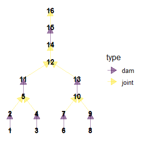

```r
gg0 <- ggnetwork(g, layout =  layout_as_tree(g %>% as.undirected, root = 16), scale = FALSE)

ggplot(gg0, aes(x = x, y = y, xend = xend, yend = yend)) +
  geom_nodes(alpha = 0.3) +
  geom_edges(alpha = 0.5,
             arrow = arrow(length = unit(10, "pt"), type = "closed"),
             aes(color = type)) +
  scale_color_viridis(discrete = TRUE)+
  geom_nodetext(aes(label = name), fontface = "bold") +
  theme_blank()
```

This function can be used to display all the graph attributes.

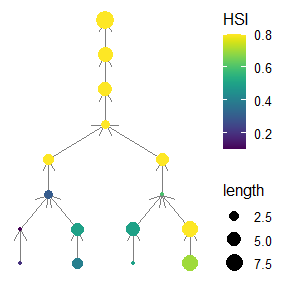

```r
ggplot(gg0, aes(x = x, y = y, xend = xend, yend = yend)) +
  geom_edges(alpha = 0.5,
             arrow = arrow(length = unit(10, "pt"), type = "open")) +
  geom_nodes(aes(size = length, color = HSI)) +
  scale_color_viridis()+
  theme_blank()
```

### Assigning network directionality

The `riverconn` package implements the function `set_graph_directionality` that allows to assign the directionality of the graph once an outlet is defined.

[figure not shown]

```r
par(mfrow=c(1,3))
g1 <- set_graph_directionality(g, field_name = "Id", outlet_name = "16")
g2 <- set_graph_directionality(g, field_name = "Id", outlet_name = "5")
plot(as.undirected(g), layout = layout_as_tree(as.undirected(g), root = 8, flip.y = FALSE))
plot(g1, layout = layout_as_tree(as.undirected(g1), root = 16, flip.y = FALSE))
plot(g2, layout = layout_as_tree(as.undirected(g2), root = 5, flip.y = FALSE))
```

## Indices calculation

The function `index_calcualtion` is used to calculate all the nuances of the CCI and RCI

Before calculation, the information on the barriers passability are needed.

```r
# Check edged and nodes attributes, add pass_u and pass_d fields
g_v_df <- igraph::as_data_frame(g, what = "vertices")
g_v_df
```

```
##    name length HSI Id
## 1     1      1 0.2  1
## 2     2      1 0.1  2
## 5     5      2 0.3  5
## 3     3      3 0.4  3
## 4     4      4 0.5  4
## 6     6      1 0.5  6
## 7     7      5 0.5  7
## 10   10      1 0.6 10
## 8     8      7 0.7  8
## 9     9      7 0.8  9
## 11   11      3 0.8 11
## 12   12      2 0.8 12
## 13   13      4 0.8 13
## 14   14      5 0.8 14
## 15   15      6 0.8 15
## 16   16      9 0.8 16
```

```r
g_e_df <- igraph::as_data_frame(g, what = "edges") %>%
  mutate(pass_u = ifelse(!is.na(id_dam),0.1,NA),
         pass_d = ifelse(!is.na(id_dam),0.7,NA))
g_e_df
```

```
##    from to id_dam  type pass_u pass_d
## 1     1  2      1   dam    0.1    0.7
## 2     2  5   <NA> joint     NA     NA
## 3     5 11      2   dam    0.1    0.7
## 4     3  4      3   dam    0.1    0.7
## 5     4  5   <NA> joint     NA     NA
## 6     6  7      4   dam    0.1    0.7
## 7     7 10   <NA> joint     NA     NA
## 8    10 13      5   dam    0.1    0.7
## 9     8  9      6   dam    0.1    0.7
## 10    9 10   <NA> joint     NA     NA
## 11   11 12   <NA> joint     NA     NA
## 12   12 14   <NA> joint     NA     NA
## 13   13 12   <NA> joint     NA     NA
## 14   14 15      7   dam    0.1    0.7
## 15   15 16   <NA> joint     NA     NA
```

```r
# Recreate graph
g <- igraph::graph_from_data_frame(d = g_e_df, vertices = g_v_df)
g
## IGRAPH e16357d DN-- 16 15 --
## + attr: name (v/c), length (v/n), HSI (v/n), Id (v/c), id_dam (e/c),
## | type (e/c), pass_u (e/n), pass_d (e/n)
## + edges from e16357d (vertex names):
##  [1] 1 ->2  2 ->5  5 ->11 3 ->4  4 ->5  6 ->7  7 ->10 10->13 8 ->9  9 ->10
## [11] 11->12 12->14 13->12 14->15 15->16
```

Index with default settings.

```r
index_calculation(g, param = 0.9)
```

```
##        num  den     index
## 1 562.6092 3721 0.1511984
```

Index with default settings, only $c_{ij}$ or $B_{ij}$ contributions

```r
index_calculation(g, B_ij_flag = FALSE)
```

```
##        num  den     index
## 1 791.8553 3721 0.2128071
```

```r
index_calculation(g, param = 0.9, c_ij_flag = FALSE)
```

```
##        num  den    index
## 1 1210.583 3721 0.325338
```

Index with default settings, only $B_{ij}$ contributions with threshold on the distance

```r
index_calculation(g, c_ij_flag = FALSE,
                  dir_distance_type = "asymmetric",
                  disp_type = "threshold", param_u = 0, param_d = 5)
```

```
##   num  den     index
## 1 413 3721 0.1109917
```

```r
index_calculation(g, c_ij_flag = FALSE,
                  dir_distance_type = "asymmetric",
                  disp_type = "threshold", param_u = 5, param_d = 10)
```

```
##    num  den     index
## 1 1045 3721 0.2808385
```

```r
index_calculation(g, c_ij_flag = FALSE,
                  dir_distance_type = "symmetric",
                  disp_type = "threshold", param = 10)
```

```
##    num  den     index
## 1 1277 3721 0.3431873
```

Index for reach, inbound connections used, only $B_{ij}$ contributions with threshold on the distance

```r
index_calculation(g, c_ij_flag = FALSE,
                  index_type = "reach", index_mode = "to",
                  dir_distance_type = "asymmetric",
                  disp_type = "threshold", param_u = 0, param_d = 5)
```

```
## # A tibble: 16 x 4
##    name    num   den  index
##    <chr> <dbl> <dbl>  <dbl>
##  1 1         1    61 0.0164
##  2 10       13    61 0.213
##  3 11        7    61 0.115
##  4 12       11    61 0.180
##  5 13        5    61 0.0820
##  6 14        7    61 0.115
##  7 15        6    61 0.0984
##  8 16        9    61 0.148
##  9 2         2    61 0.0328
## 10 3         3    61 0.0492
## 11 4         7    61 0.115
## 12 5         8    61 0.131
## 13 6         1    61 0.0164
## 14 7         6    61 0.0984
## 15 8         7    61 0.115
## 16 9         7    61 0.115
```

```r
index_calculation(g, c_ij_flag = FALSE,
                  dir_distance_type = "asymmetric",
                  index_type = "reach", index_mode = "to",
                  disp_type = "threshold", param_u = 5, param_d = 10)
```

```
## # A tibble: 16 x 4
##    name    num   den  index
##    <chr> <dbl> <dbl>  <dbl>
##  1 1        14    61 0.230
##  2 10       18    61 0.295
##  3 11       33    61 0.541
##  4 12       35    61 0.574
##  5 13       31    61 0.508
##  6 14       18    61 0.295
##  7 15       13    61 0.213
##  8 16       15    61 0.246
##  9 2        14    61 0.230
## 10 3         7    61 0.115
## 11 4        11    61 0.180
## 12 5        33    61 0.541
## 13 6         6    61 0.0984
## 14 7        14    61 0.230
## 15 8         7    61 0.115
## 16 9        21    61 0.344
```

```r
index_calculation(g, c_ij_flag = FALSE,
                  index_type = "reach", index_mode = "to",
                  dir_distance_type = "symmetric",
                  disp_type = "threshold", param = 10)
```

```
## # A tibble: 16 x 4
##    name    num   den index
##    <chr> <dbl> <dbl> <dbl>
##  1 1        16    61 0.262
##  2 10       28    61 0.459
##  3 11       26    61 0.426
##  4 12       41    61 0.672
##  5 13       31    61 0.508
##  6 14       23    61 0.377
##  7 15       22    61 0.361
##  8 16       15    61 0.246
##  9 2        20    61 0.328
## 10 3        14    61 0.230
## 11 4        16    61 0.262
## 12 5        25    61 0.410
## 13 6        11    61 0.180
## 14 7        20    61 0.328
## 15 8        14    61 0.230
## 16 9        26    61 0.426
```

## Prioritization calculation and visualization

```r
dams_metadata <- data.frame("id_dam" =  c("1", "2", "3", "4", "5", "6", "7"),
                            "pass_u_updated" = c(1, 1, 1, 1, 1, 1, 1),
                            "pass_d_updated" = c(1, 1, 1, 1, 1, 1, 1))
dams_metadata
```

```
##   id_dam pass_u_updated pass_d_updated
## 1      1              1              1
## 2      2              1              1
## 3      3              1              1
## 4      4              1              1
## 5      5              1              1
## 6      6              1              1
## 7      7              1              1
```

```r
d_index_calculation(g,
                    barriers_metadata = dams_metadata,
                    id_barrier = "id_dam",
                    parallel = FALSE, ncores = 3,
                    param_u = 10,  param_d = 10, param = 0.5,
                    index_type = "full",
                    dir_distance_type = "asymmetric",
                    disp_type = "threshold")
```

```
##   id_dam      num  den     index  index_bl   d_index
## 1      1 761.3266 3721 0.2046027 0.2006519  1.968976
## 2      2 906.0160 3721 0.2434872 0.2006519 21.348084
## 3      3 787.2481 3721 0.2115690 0.2006519  5.440798
## 4      4 771.3265 3721 0.2072901 0.2006519  3.308324
## 5      5 986.0332 3721 0.2649915 0.2006519 32.065261
## 6      6 837.7657 3721 0.2251453 0.2006519 12.206919
## 7      7 824.7457 3721 0.2216463 0.2006519 10.463074
```

Calculated index can be joined with the original graph and plotted to check spatial patterns.

```r
d_index <- d_index_calculation (g,
                                barriers_metadata = dams_metadata,
                                id_barrier = "id_dam",
                                parallel = FALSE, ncores = 3,
                                param_u = 10,  param_d = 10,
                                index_type = "full",
                                B_ij_flag = FALSE)

# Check edged and nodes attributes
g_v_df <- igraph::as_data_frame(g, what = "vertices")
g_v_df
```

```
##    name length HSI Id
## 1     1      1 0.2  1
## 2     2      1 0.1  2
## 5     5      2 0.3  5
## 3     3      3 0.4  3
## 4     4      4 0.5  4
## 6     6      1 0.5  6
## 7     7      5 0.5  7
## 10   10      1 0.6 10
## 8     8      7 0.7  8
## 9     9      7 0.8  9
## 11   11      3 0.8 11
## 12   12      2 0.8 12
## 13   13      4 0.8 13
## 14   14      5 0.8 14
## 15   15      6 0.8 15
## 16   16      9 0.8 16
```

```r
g_e_df <- igraph::as_data_frame(g, what = "edges") %>%
  left_join(d_index, by = "id_dam")
g_e_df
```

```
##    from to id_dam  type pass_u pass_d       num  den     index  index_bl
## 1     1  2      1   dam    0.1    0.7  807.3490 3721 0.2169710 0.2128071
## 2     2  5   <NA> joint     NA     NA        NA   NA        NA        NA
## 3     5 11      2   dam    0.1    0.7 1008.4973 3721 0.2710286 0.2128071
## 4     3  4      3   dam    0.1    0.7  837.5552 3721 0.2250887 0.2128071
## 5     4  5   <NA> joint     NA     NA        NA   NA        NA        NA
## 6     6  7      4   dam    0.1    0.7  818.9726 3721 0.2200947 0.2128071
## 7     7 10   <NA> joint     NA     NA        NA   NA        NA        NA
## 8    10 13      5   dam    0.1    0.7 1184.2933 3721 0.3182729 0.2128071
## 9     8  9      6   dam    0.1    0.7  976.2077 3721 0.2623509 0.2128071
## 10    9 10   <NA> joint     NA     NA        NA   NA        NA        NA
## 11   11 12   <NA> joint     NA     NA        NA   NA        NA        NA
## 12   12 14   <NA> joint     NA     NA        NA   NA        NA        NA
## 13   13 12   <NA> joint     NA     NA        NA   NA        NA        NA
## 14   14 15      7   dam    0.1    0.7 1223.1558 3721 0.3287170 0.2128071
```

[output cut: 17 more lines]

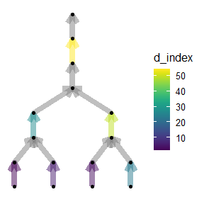

```r
# Recreate graph
g <- igraph::graph_from_data_frame(d = g_e_df, vertices = g_v_df)
g
## IGRAPH e37479f DN-- 16 15 --
## + attr: name (v/c), length (v/n), HSI (v/n), Id (v/c), id_dam (e/c),
## | type (e/c), pass_u (e/n), pass_d (e/n), num (e/n), den (e/n), index
## | (e/n), index_bl (e/n), d_index (e/n)
## + edges from e37479f (vertex names):
##  [1] 1 ->2  2 ->5  5 ->11 3 ->4  4 ->5  6 ->7  7 ->10 10->13 8 ->9  9 ->10
## [11] 11->12 12->14 13->12 14->15 15->16

# Fortify and plot graph
gg0 <- ggnetwork(g, layout =  layout_as_tree(g %>% as.undirected, root = 16), scale = FALSE)
ggplot(gg0, aes(x = x, y = y, xend = xend, yend = yend)) +
  geom_edges(alpha = 0.5, size = 3,
             arrow = arrow(length = unit(10, "pt"), type = "open"),
             aes(color = d_index)) +
  geom_nodes() +
  scale_color_viridis()+
  theme_blank()
```

## References and key literature

Belletti, Barbara, et al. “More than one million barriers fragment Europe’s rivers.” Nature 588.7838 (2020): 436-441.

Cote, D., Kehler, D. G., Bourne, C., & Wiersma, Y. F. (2009). A new measure of longitudinal connectivity for stream networks. Landscape Ecology, 24(1), 101-113.

Kolaczyk, E. D., & Csárdi, G. (2014). Statistical analysis of network data with R (Vol. 65). New York: Springer.

Jumani, S., Deitch, M. J., Kaplan, D., Anderson, E. P., Krishnaswamy, J., Lecours, V., & Whiles, M. R. (2020). River fragmentation and flow alteration metrics: a review of methods and directions for future research. Environmental Research Letters.